# The State of the World: Education

Shreya Kumar

10/28/2020

It is no secret that education is important. Education grants people the opportunity to change their life or current situation by equipping them with the knowledge they need to succeed in any role. A good education can help students to find their passions and help them to form opinions and new perspectives on the world around them. This understanding about the importance of education has been around since the beginning, but there is no doubt that education has changed over the years. Currently, the world is in its 8th month of the COVID-19 pandemic. This pandemic has changed the world in many ways with education being at the top of that list. The shift from in-person to online schooling has had a major impact on what was known about education and curriculum for every school. We are widely aware of this change to the state of education globally at this time, but what other changes have occurred in the past 50 years that we have overlooked?

In order to understand the state of the world in terms of education in the past 50 years, there are certain determinants that have to be considered. There are many variables that explain the state of education such as Population, Literacy Rates, and Average Years of Schooling. In this report, we will go into all the determinants that have been essential in education and note any changes that have occurred over time.

## Population

To begin, we are going to look at the first determinant of Education which is population. Before we can relate the population back to education, it’s important to see how the population increased on a global scale during this time. To consolidate global data, we are going to take a look at the population of each continent.

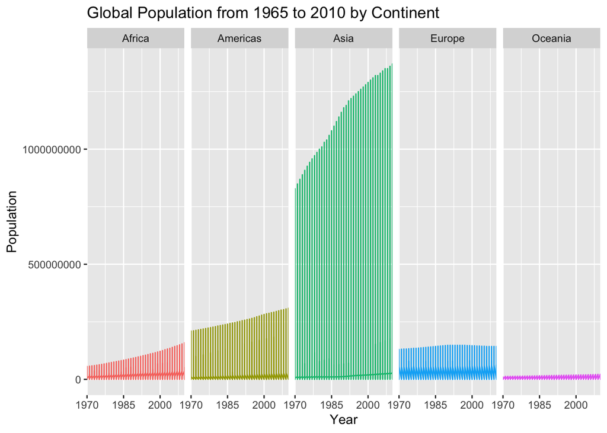

As you can see from the plot, the population has steadily increased over time with Asia having the most drastic increase over the years. Almost all continents are seeing their population at an all time high in 2010 besides Europe. From here, we can relate this population data back to education by comparing the population in each country to another determinant, literacy rate. Literacy is a key measure of a population’s education. According to UNESCO the measurement of literacy as the ability to both read and write a short, simple statement about one’s own life. In the graph below we are going to take a look at the world literacy from the same time period of 1965 - 2010.

## World Literacy

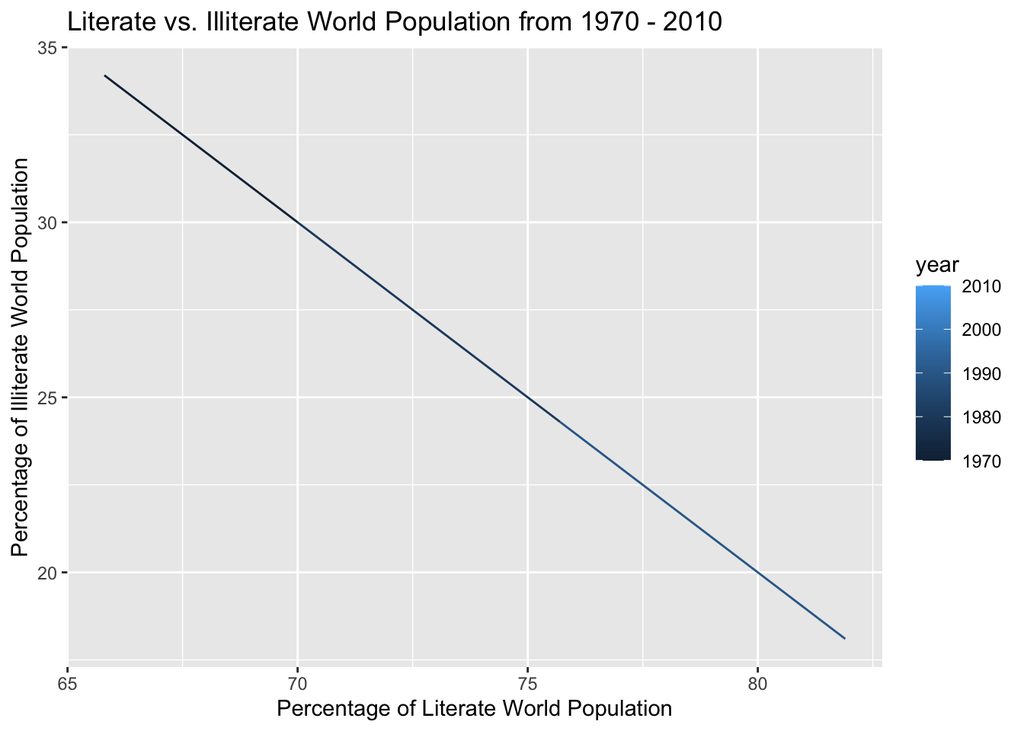

This is such an interesting graph to look at because this provides us with more information than we think. As we can see, literacy rates grew constantly over the course of the 40 years as can be shown by the legend colors. We are able to make the conclusion that global literacy has grown substantially over the past 40 years as the population of the world continued to grow as well. We can take a look to see another important determinant for education, gender.

## Gender

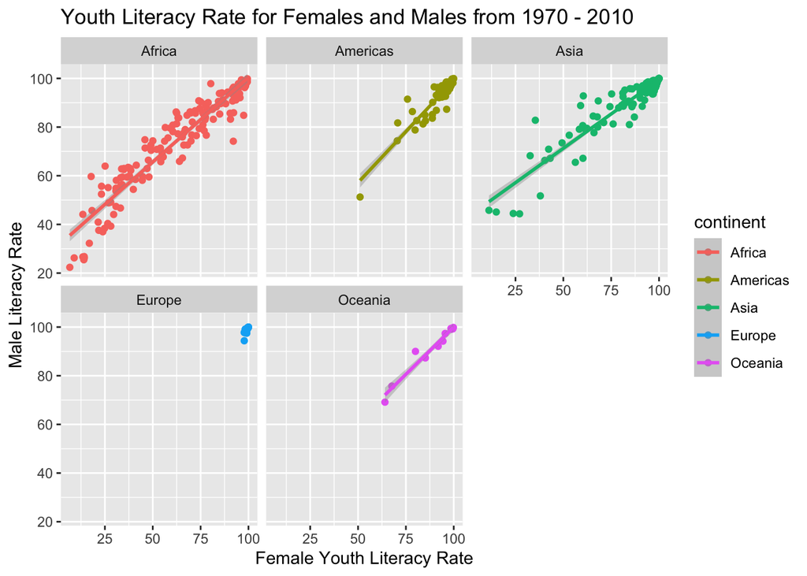

Since the percentage of those who are literate had seen an increase, it would be interesting to see how each continent’s income changed to account for that. On average, individuals who are more highly educated are paid more than those who are less well educated. Another way to think about the relationship between education and income is an investment in human capital. The term for the higher income that results from having a college degree is often referred to as the “college wage premium” and research shows this premium has grown overtime.

## World Income

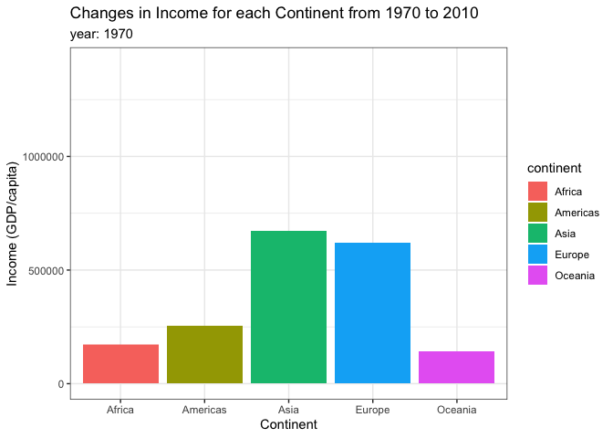

The plot shown above is a visualization of that effect as you see the income of each continent over time. The interesting thing to note from this is the dramatic upward trend of income levels from the years of 2000 onwards for all continents. Overall, this was consistent with all the plots above. We can now measure the population’s overall education level by taking a look at a plot representing the average years of schooling by the population. According to Our World in Data this “allows an analysis of the ‘stock of human capital’ that a population has at any given point in time”.

## Average Years in School

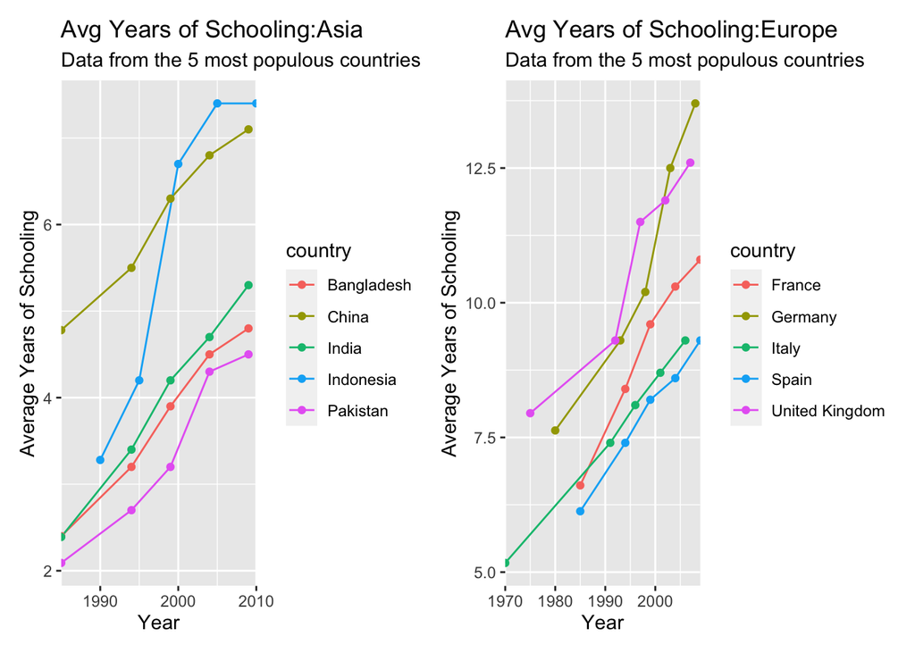

We can take a look at this relationship and actually create a comparison between continents. As you can see here we are comparing the years of schooling for Europe to Asia. Note that the average years of schooling for 5 most populous countries in Europe is almost twice that of Asia’s. Once again, we are seeing a consistent upwards trend in the terms of the average years of schooling. Taking into account the previous plots we’ve seen, we can associate a rise in the mean years of schooling to “increased appreciation of the benefits of education to the individual and society,as well as and increased government provision”. Let’s now take a look at government expenditure on education over the years to see if that statement holds true.

## Government Expenditure

This table shows the government expenditure on education for each continent in the year 1975 versus the year 2010. We notice that almost every continent has seen an expansion in government expenditure. Government spending can increase labor productivity and enable higher long-term economic growth which was mirrored in the plot on income.

Government Expenditure by Continent

Given as a share of GDP

| Continents | Expenditure_1975 | Expenditure_2010 |
| --- | --- | --- |
| Europe | 4.712739 | 5.503844 |
| Asia | 2.837591 | 3.712447 |
| Americas | 3.818583 | 5.367719 |
| Africa | 5.033596 | 4.308268 |
| Oceania | 5.167530 | 7.523153 |

## Conclusion

### Works Cited

Data. (n.d.). Retrieved October 30, 2020, from https://www.gapminder.org/data/

Roser, M., & Ortiz-Ospina, E. (2016, August 13). Literacy. Retrieved October 30, 2020, from https://ourworldindata.org/literacy

Snyder, T. (1993, January 19). 120 Years of American Education: A Statistical Portrait. Retrieved October 30, 2020, from https://nces.ed.gov/pubsearch/pubsinfo.asp?pubid=93442

Wolla, S., & Sullivan, J. (n.d.). Education, Income, and Wealth. Retrieved October 30, 2020, from https://research.stlouisfed.org/publications/page1-econ/2017/01/03/education-income-and-wealth/